# Full Project - UK 2016 EU Referendum

Simon Freeman

17 juillet 2019

# Project Description

## Introduction

On 23rd June 2016 the UK held a referendum asking the following question:

“Should the United Kingdom remain a member of the European Union or leave the European Union?”

All British citizens over the age of 18 were allowed to vote unless, like me, they had lived outside of the UK for more than 15 years (including those actively living in the European Union). Non-British EU citizens living and working in the UK also had no vote.

The overall result was as follows:

|  | Votes | Percentage |
| --- | --- | --- |
| Leave | 17 410 742 | 51.89% |
| Remain | 16 141 241 | 48.11% |

|  | Votes | Percentage |
| --- | --- | --- |
| Valid Votes | 33 551 983 | 99.92% |
| Invalid Votes | 25 359 | 0.08% |
| Total Votes | 33 577 342 | 100.00% |

|  | Voters | Turnout |
| --- | --- | --- |
| Registered Voters/Turnout | 46 500 001 | 72.21% |

This was the first time that a referendum result had gone against the preferred option of the UK Government.

## European Union

The European Union was created following the Treaty of Rome in 1957 by Belgium, France, Italy, Luxembourg, the Netherlands and West Germany with the aim of bringing about a common market and customs union. An early accomplishment of the EU was the establishment of common agriculture pricing leading to the Common Agriculture Policy.

The UK first applied to join the Union in 1961, but their application was vetoed by French President, Charles de Gaulle, possibly seeing it as a “Trojan Horse” for unwanted US influence. Following the change of French President at the end of the 1960s, negotiations restarted in 1970 with the UK finally joining the EU in January 1973.

In 1975 there was a UK referendum as to whether the UK should remain in the European Community (now EU). At that time 67.23% of those voting, voted to Remain.

The European Union is currently made up of 28 member countries 19 of which share a common currency, the Euro.

## Background to 2016 Referendum

Following the 2007 Recession there has been an increase in Populism throughout Europe, coming with a widespread idea that governments and traditional political parties are unresponsive to the needs of the average citizen. In many countries this has led both to the creation of new political parties and to a significantly increased vote for Nationalist parties.

The UK Independence Party (UKIP) emerged and started to gain significant momentum. Knowing that no sitting government had ever lost a referendum (including the recent Scottish Independence vote), the Conservative party made a manifesto commitment ahead of the 2015 general election to hold a referendum on continued EU membership probably in order to take votes from UKIP.

In the run up to the Referendum both sides (Leave & Remain) tended to appeal to emotion rather than presenting the relevant facts and figures of what leaving the EU would mean in practice. (The very opposite of a data-driven decision). Some three years later, and a couple of months after the original exit date, it is now apparent that the separation from the EU is much messier and complex than anticipated and that there is deadlock both politically and throughout the country as to what would constitute an acceptable exit. It has also forced the resignation of the Prime Minister who was unable to steer a path through the deadlock.

## Project Proposal

My proposal is to create a dataset including the referendum results, political results from the 2015 elections and socio-economic data from Census, EU and UK National Statistics sources and use it to examine relationships between the Leave Percent and available variables to see what might be significant. Along the way I’ll attempt to test some of the commonly held views about the referendum voting to see what support there might be for them.

Then I want to use the same data to create a good predictive model for the Leave Percent by voting area.

**NB** There was a notable regional aspect to the voting with Northern Ireland (44.22% Leave) and Scotland (38.00% Leave). Due to the consistency of these regional results I’ve decided to concentrate this study on England & Wales only as here we see the full range of results. I’ve also excluded Gibraltar where, maybe not surprisingly for a voting area in continental Europe, the result was 4.09% Leave.

The distribution of the Leave vote can be seen in the following graphic. (The blank areas generally show remote areas often in National Parks where there is no Postcode data).

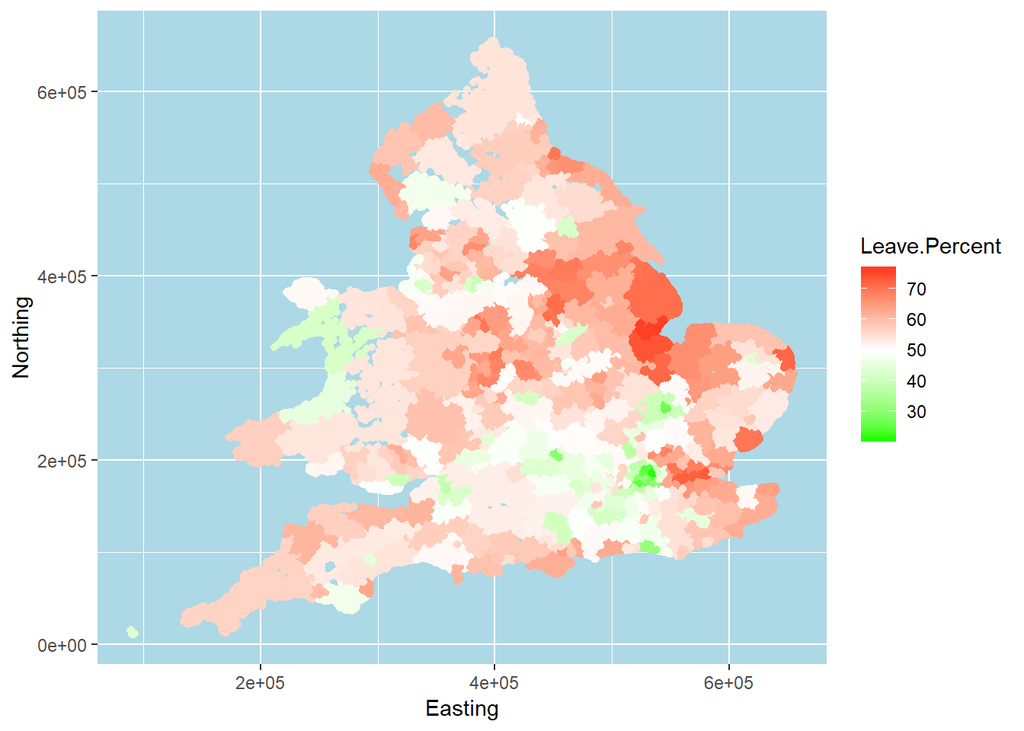

# Data Cleaning

## Sources and Acknowledgements

The clean referendum dataset comes from a series of individual sources as below. I would like to acknowledge the sources of each of them for the work they’ve put in to making these data available. In particular to John Lees-Miller, Hope Thomas & Andrew Weeks for the work they’ve done in putting together the EU funding data which can be seen on the myeu.uk website.

| Dataset | Source |
| --- | --- |
| age_group.csv | Office for National Statistics: table nomis QS110EW |
| disposable_income_per_head.csv | Office for National Statistics “Regional Gross Disposable Household Income (GDHI) by Local Authority” |
| economic_activity.csv | Office for National Statistics: table nomis QS601EW |
| election_results.csv | 2015 General Election results |
| ethnicity_local_authority.csv | Office for National Statistics: table nomis LC2205EW |
| eu_funding.csv | myeu.uk “Stories with Westminster Parliamentary Constituency” |
| EU-referendum-result-data.csv | Electoral Commission “EU Referendum Result” |
| highest_qualification.csv | Office for National Statistics: table nomis QS501EW |
| house_prices.csv | Land Registry data.gov.uk “Price paid data YTD” |
| National_Statistics_Postcode_Lookup_UK.csv | Camden.gov.uk “National Statistics Postcode Lookup” |
| passport_held.csv | Office for National Statistics: table nomis QS212EW |
| social_grade.csv | Office for National Statistics: table nomis QS611EW |

## Overall Methodology

In some cases the data is directly available at the same level as the referendum results, in others I’ve needed to convert to this level.

In particular this meant that I needed to use a Postcode lookup. Unfortunately the best dataset I found had some missing Postcodes (despite 500 000 lines) so I decided on an iterative approach.

```
        1.  If the full postcode was in the lookup use that;
  Else  2.  Take the final character off the missing postcode and choose the Local Authority with the
        highest count for that combination;
  Else  3.  Take the final two characters off the missing postcode and choose the Local Authority with the
        highest count for that combination.
```

This works because UK postcodes are very detailed and a full postcode may only apply to 20 houses. There will almost certainly be a very small amount of missorting, but this shouldn’t have any noticeable significance on the cleaned dataframe.

Once the data is all held at the Local Authority level (thus aligned to the Referendum results), the clean dataset is formed by joining the individually cleaned sources together.

## Specific Cleaning

### Ethnicity Data

This is a very complex dataset cross-referencing Geography of Birth with Nationality with Ethnic Grouping. I’ve reduced the number of groupings to the following and converted them to a percentage of the population:

| Grouping |
| --- |
| White.British.Percent |
| Non.British.White.UKborn.Percent |
| British.Non.White.UKborn.Percent |
| EUborn.Immigrants.Percent |
| RoW.Immigrants.Percent |

**NB** RoW means “Rest of the World”

Why these groupings? Was the referendum affected by the number of immigrants from the EU, the number of immigrants from elsewhere, or the number of people who are not “White”? Is it different for second (or more) generation immigrants?

### Postcode Data

As described above I’ve created 3 lookup datasets for the full postcode, for the postcode minus the last character, and the postcode minus the last two characters.

### EU Funding Data

I’ve taken the EU Funding at a Postcode level, converted to Millions of GB Pounds, and applied the three postcode lookup tables in turn only using a less detailed one if there’s no match on the previous level in order to get the Local Authority for each line. I’ve then summarised at the Local Authority level.

### House Price Data

I’ve taken the House Price at a Postcode level, converted to Thousands of GB Pounds, and applied the three postcode lookup tables in turn only using a less detailed one if there’s no match on the previous level in order to get the Local Authority for each line. I’ve also excluded Property Type = “O” (Other) from the dataset as this could be a very different type of property (eg Commercial Premises) which could distort the other data. I’ve then summarised at the Local Authority level.

I decided to combine the Residential Property Types into one as my intention was to concentrate on the overall cost of living in an area rather than on the mix of Houses vs Flats - my assumption being that the market would decide that mix.

### Passport Ownership

From a simpler dataset I’ve summarised the percentages of people with a British Passport and No Passport. With over 54 million visits into the EU from the UK in 2017 (making it the most popular destination for UK travel) which would become more complicated after a UK exit, I wanted to see if the lack of a passport might influence the results.

### Education

Is there a link between education and voting patterns? Although both Remain and Leave campaigns were led by educated people there has been some speculation that there may be some correlation. I grouped the dataset into the following and created percentages:

| Grouping | Description |
| --- | --- |
| Degree.Percent | University educated |
| Formal.Education.to.16.Percent | Left school at minimum legal age |

### Election Results by Political Party

This data comes from the UK general election in 2015, the year before the referendum and I’ve loaded it without making any changes in R. I wanted to know if there were any political party links to the voting outside of those of nationalist parties (mostly UKIP) where a correlation is expected.

### Age Demographics

After the referendum there was speculation that the Leave vote was very high amongst the older voters and a perceived outcry from younger voters that their desire to remain in the EU was not being heard. What does the data say? In this case the data didn’t require any extra manipulations.

### Social Grouping

Does the type of social grading (largely based on current or previous employment within a household) influence voting patterns? As the group names are not self-evident I’ve included a description. No cleaning was necessary on this data outside of giving consistent names to the fields.

| Grouping | Description | % UK Population |
| --- | --- | --- |
| AB.Percent | Higher & intermediate managerial, administrative, professional jobs | 22.17 |
| C1.Percent | Supervisory, clerical & junior managerial, administrative, professional jobs | 30.84 |
| C2.Percent | Skilled manual occupations | 20.94 |
| DE.Percent | Semi-skilled & unskilled manual occupations, Unemployed and lowest grade jobs | 26.05 |

### Economic Activity

The EU is the biggest export market for UK businesses and under a Remain vote would continue to have no trade tarifs. Did this influence the voting patterns for people in employment or employers? Were the unemployed threatened by the free movement of people within the EU, causing more competition for jobs?

I’ve taken the original data set and reduced the number of groups on the basis that it doesn’t make any logical difference if someone works Full time or Part time or if someone who is self-employed also employs others or not. A percentage has then been assigned to each group.

| Grouping | Description |
| --- | --- |
| Employee.Percent | Both Full and Part time |
| SelfEmployed.Percent | Both with and without Employees |
| Unemployed.Percent | All unemployed |
| Student.Percent | All students |
| Retired.Percent | All retired |
| Other.Activity.Percent | Homemakers, Longterm Sick and Other |

### Income

I’ve taken this data as supplied except a conversion to Thousands of GB Pounds.

## Final Dataset

In order to create my clean dataset I’ve taken the Referendum results file, selected the columns to keep and renamed them for consistency. I’ve then made left_joins with the other data matching on Local Authority Code and Local Authority Name.

The structure of the new dataset is as follows:

```
## 'data.frame':    348 obs. of  46 variables:
##  $ Region.Code                     : Factor w/ 10 levels "E12000001","E12000002",..: 6 6 6 6 6 6 6 6 6 6 ...
##  $ Region.Name                     : Factor w/ 10 levels "East","East Midlands",..: 1 1 1 1 1 1 1 1 1 1 ...
##  $ LA.Code                         : chr  "E06000031" "E06000032" "E06000033" "E06000034" ...
##  $ LA.Name                         : chr  "Peterborough" "Luton" "Southend-on-Sea" "Thurrock" ...
##  $ Turnout.Percent                 : num  72.3 66.3 72.9 72.8 72.1 ...
##  $ Total.Votes                     : int  87469 84616 93939 79950 86135 158894 57852 48124 52649 99990 ...
##  $ Remain                          : int  34176 36708 39348 22151 41497 69670 42682 23599 15055 45729 ...
##  $ Leave                           : int  53216 47773 54522 57765 44569 89134 15117 24487 37571 54198 ...
##  $ Rejected                        : int  77 135 69 34 69 90 53 38 23 63 ...
##  $ Remain.Percent                  : num  39.1 43.5 41.9 27.7 48.2 ...
##  $ Leave.Percent                   : num  60.9 56.5 58.1 72.3 51.8 ...
##  $ Rejected.Percent                : num  0.09 0.16 0.07 0.04 0.08 0.06 0.09 0.08 0.04 0.06 ...
##  $ Age.16.to.24.Percent            : num  14.8 17.4 12.8 14.2 13.6 ...
##  $ Age.25.to.34.Percent            : num  20.2 22.5 16.5 18.7 16.5 ...
```

[output cut: 32 more lines]

# Data Analysis

## Introductory Graphics

### Distribution of Leave Percentage

As can be seen here there is a main group which is roughly normally distributed with a small cluster of low Leave Percentages. Where is this cluster coming from?

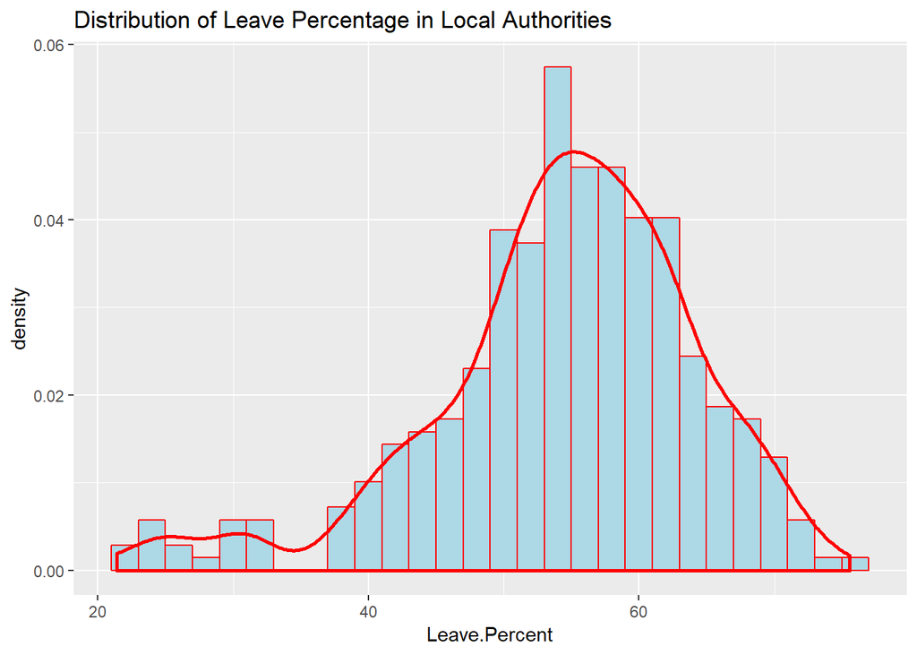

Summary Stats for Referendum Leave Percentages

| Min. | 1st Qu. | Median | Mean | 3rd Qu. | Max. |
| --- | --- | --- | --- | --- | --- |
| 21.38 | 50.3475 | 55.285 | 54.42848 | 60.8675 | 75.56 |

### Regional View of Results

As a reminder, when setting up this dataset I decided to exclude Northern Ireland and Scotland (and Gibraltar) because their results appeared to be more heavily influenced by their regional geography more than any other factor.

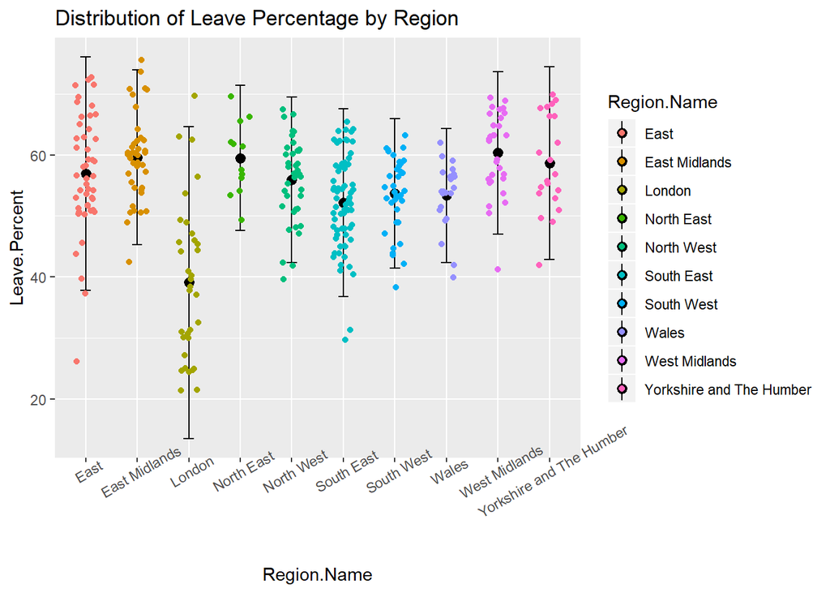

Assuming that local authorities with universities would have a higher percentage of students we can check the “university” effect in the following graphic.

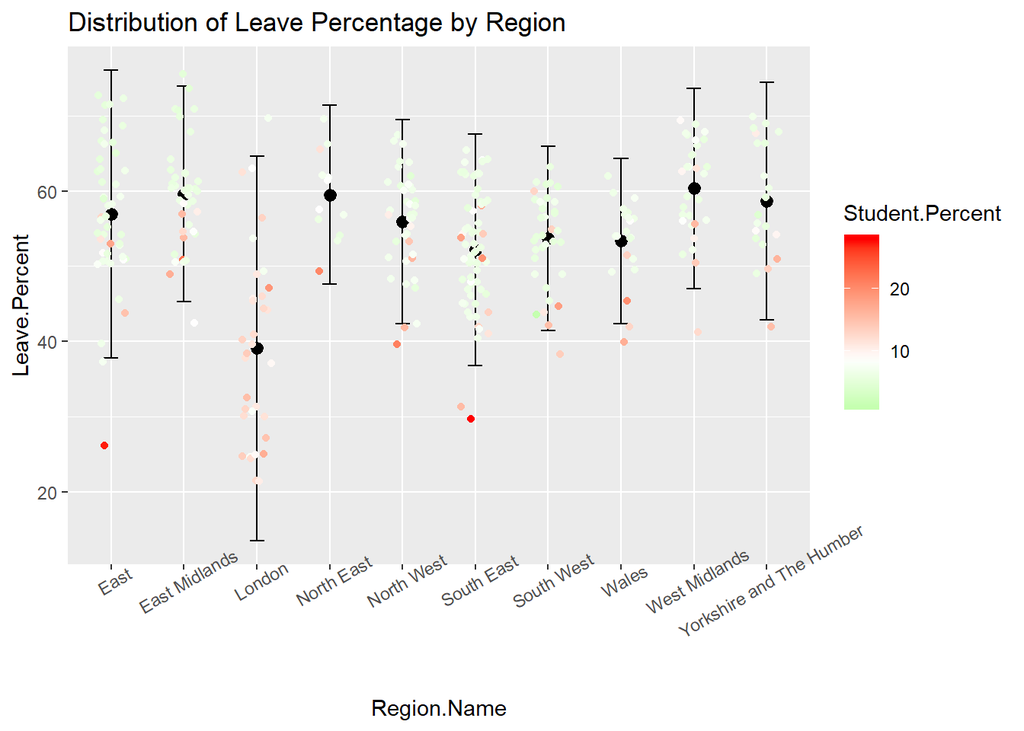

This does indeed show a tendency for local authorities with higher percentages of students to be at the lower end of the results for each Region.

### Correlation to Leave Percent

It can never be stated too many times that “Correlation is not Causation”. That is to say that a strong correlation between two variables in a dataset does not necessarily mean that one has caused the other - that might be the case or equally it could be a coincidence. Sometimes Correlation can also strongly depend on outlying data points having undue influence on the overall result.

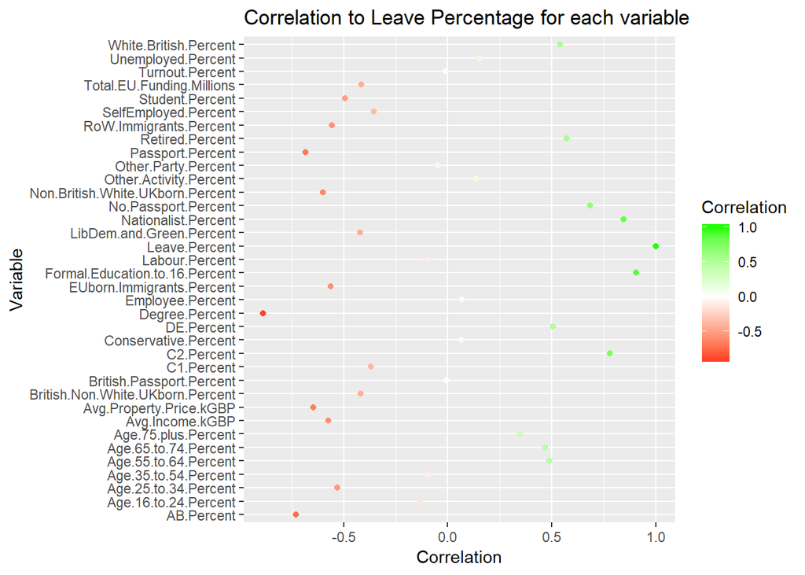

#### Highest Leave Correlations

| Variable | Correlation |
| --- | --- |
| Leave.Percent | 1.0000000 |
| Formal.Education.to.16.Percent | 0.9066375 |
| Degree.Percent | -0.8869838 |
| Nationalist.Percent | 0.8446427 |
| C2.Percent | 0.7790809 |
| AB.Percent | -0.7295802 |
| No.Passport.Percent | 0.6835456 |
| Passport.Percent | -0.6835456 |
| Avg.Property.Price.kGBP | -0.6453282 |
| Non.British.White.UKborn.Percent | -0.6010070 |
| Avg.Income.kGBP | -0.5732473 |
| Retired.Percent | 0.5728328 |
| EUborn.Immigrants.Percent | -0.5633781 |
| RoW.Immigrants.Percent | -0.5572567 |
| White.British.Percent | 0.5414477 |
| Age.25.to.34.Percent | -0.5320429 |
| DE.Percent | 0.5066710 |

# Detailed Visuals by Variable Category

## Age Demographics

PROPOSITION: People over a certain age voted heavily to leave and younger people voted to remain.

#### Correlation

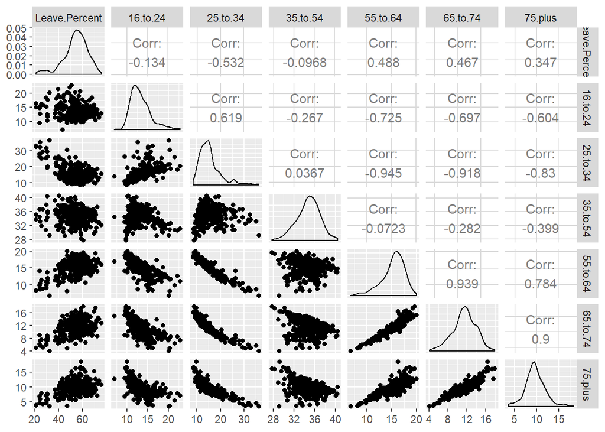

This does show that correlation for percentage of younger voters is towards Remain and older voters is towards Leave. But is this significant? Let’s consider two groups that have been talked about - one that remembers UK prior to EU membership and one which grew up post-Thatcher.

Correlation Table

|  | Leave.Percent | Under.34.Percent | Over.55.Percent |
| --- | --- | --- | --- |
| Leave.Percent | 1.0000000 | -0.4366270 | 0.4546684 |
| Under.34.Percent | -0.4366270 | 1.0000000 | -0.9438878 |
| Over.55.Percent | 0.4546684 | -0.9438878 | 1.0000000 |

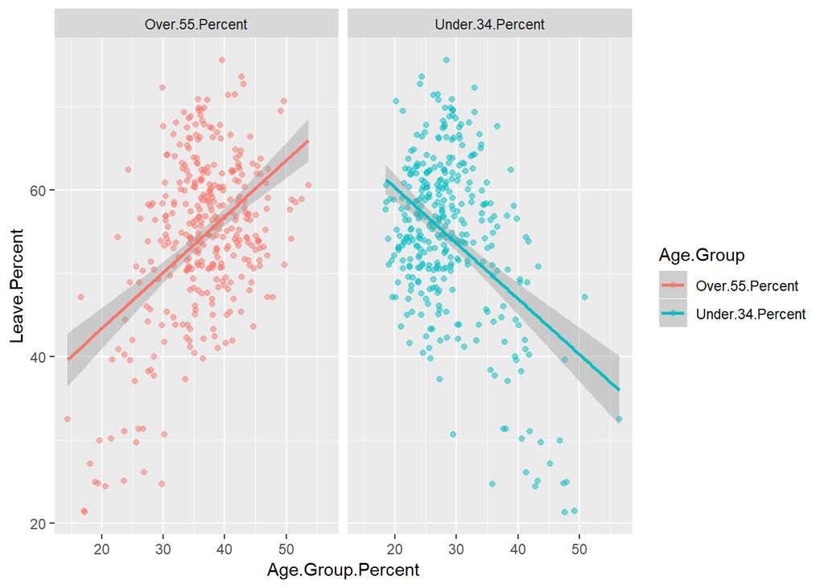

This continues to show a general tendance towards the Proposition BUT not very convincing. Internet research suggests a proposition: there was a lower turnout in the younger demographics than in the older demographics.

#### Correlation between Age Demographics and Turnout

| Variable | Correlation |
| --- | --- |
| Age.16.to.24.Percent | -0.7351880 |
| Age.25.to.34.Percent | -0.6084077 |
| Age.35.to.54.Percent | 0.2883572 |
| Age.55.to.64.Percent | 0.6079245 |
| Age.65.to.74.Percent | 0.5580229 |
| Age.75.plus.Percent | 0.5490140 |

Although only indicative this shows that the larger the population of over 55s the higher the turnout and the the larger the population of under 34s the lower the turnout which is in line with the proposition.

## Professional Activity

PROPOSITION:

1. Students voted Remain and Retired people voted Leave.
2. The Unemployed wanted to stop EU immigration to increase the jobs available for UK nationals.

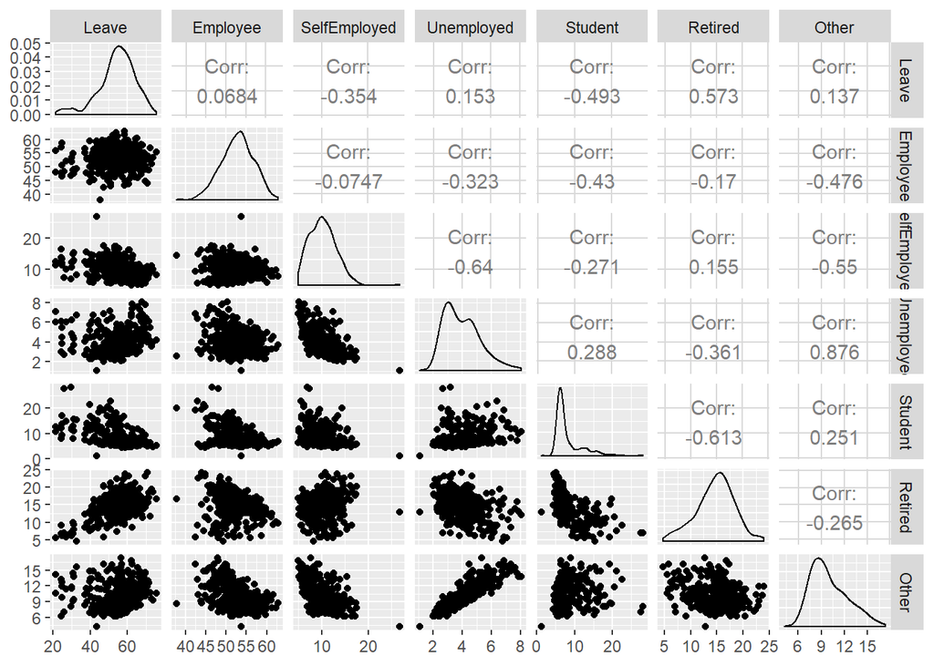

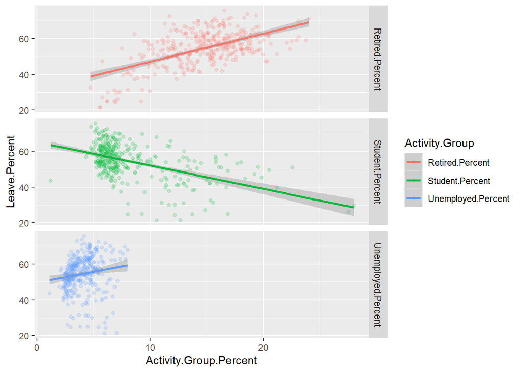

The correlations generally support the first proposition, but the correlations of around +/- 0.5 are not particularly strong.

The correlation to Unemployment is rather low so doesn’t appear to support the proposition.

## Education Levels

PROPOSITION:

1. Higher education levels correspond to a lower Leave vote (and vice versa).

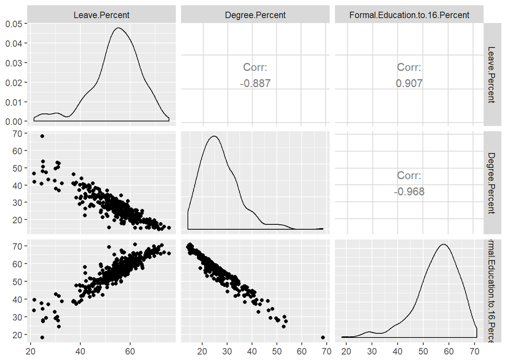

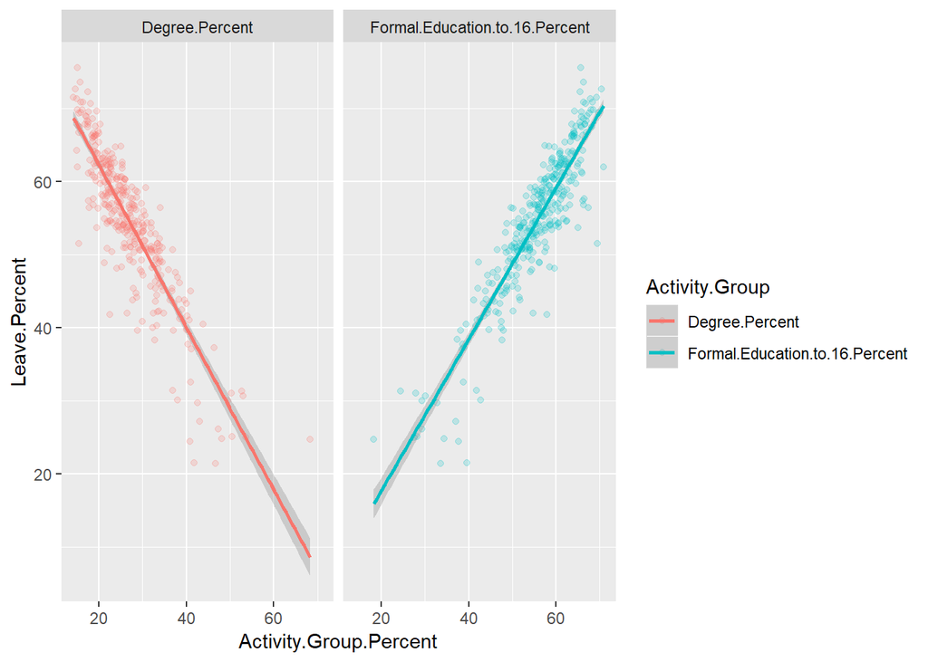

There is a strong correlation between the percentages of high (Degree) or low (<16) education within a population and the percentage for Remain and Leave respectively.

Note that as the correlation between Degree.Percent and Formal.Education.to.16.Percent is very strongly negative, it’s unlikely that both will need to be included in a prediction model.

## Political Party Support

PROPOSITION:

1. The only relevant link to political party support is for the Nationalist Parties (mainly UKIP).

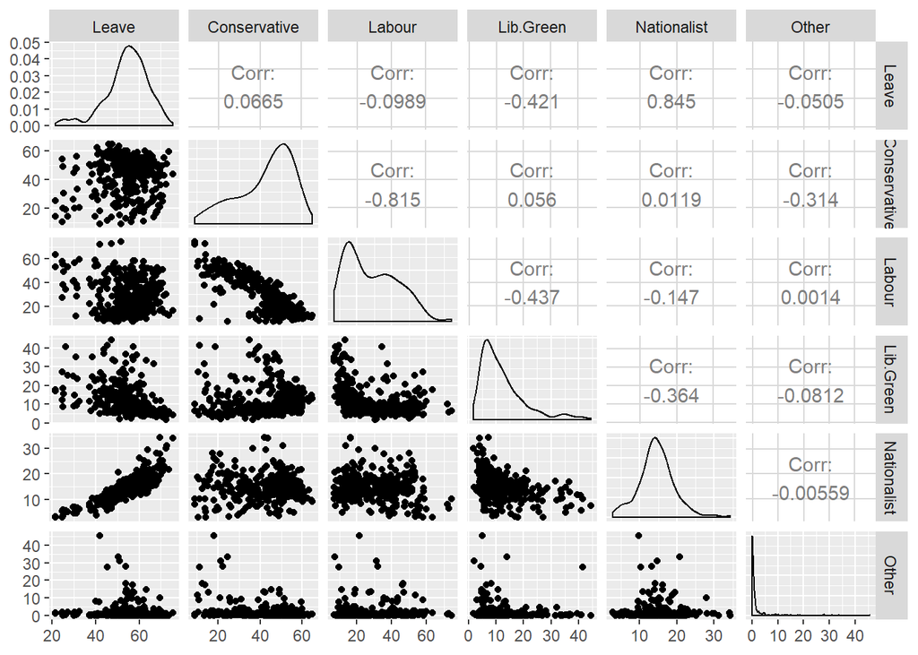

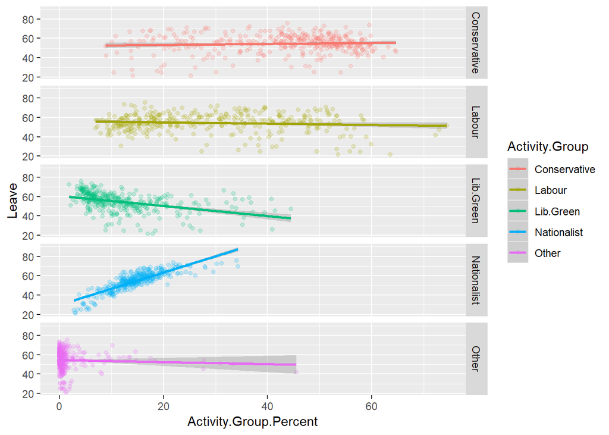

Higher votes for a Nationalist Party (mainly UK Independence Party) preceeding the referendum is strongly correlated to a higher Leave vote. Otherwise the links are not particularly strong.

Note that as the correlation between Conservative.Percent and Labour.Percent is fairly strongly negative, it’s less likely that both will need to be included in a prediction model.

## Ethnicity

PROPOSITION:

One of the main messages preceeding the referendum was the desire to reduce EU immigration.

1. Higher levels of EU immigrants in an area increases the Leave vote.
2. Higher levels of more obvious immigrants (Rest of World immigrants will generally look different) increases the Leave vote.

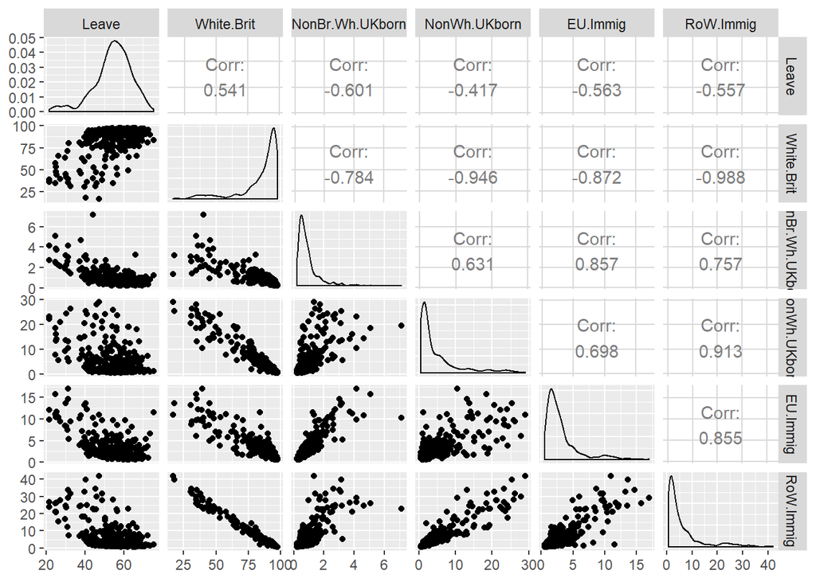

Although these correlation are not high they are interesting in that the only grouping with a positive correlation to the Leave Percent is White British. That is to say that the higher the percentage of immigrants or descendants of immigrants the greater the tendency to a lower Leave vote. Interestingly this is much the same tendency whether these groups were able to vote or not.

## Passport Holders

PROPOSITION:

1. As travel for business and leisure would become more difficult following an EU exit, the higher the percentage of passport holders the lower the Leave vote.

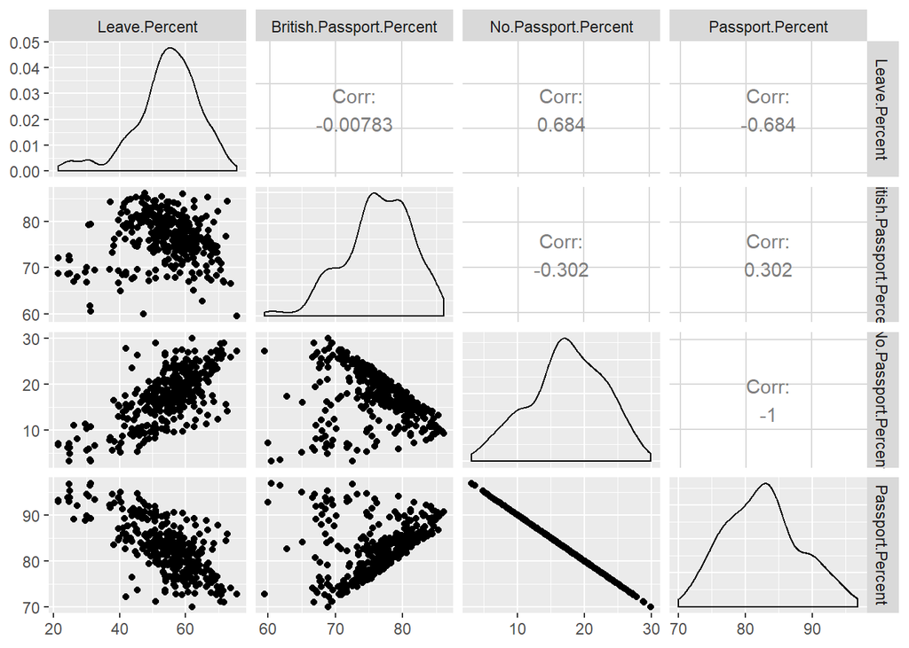

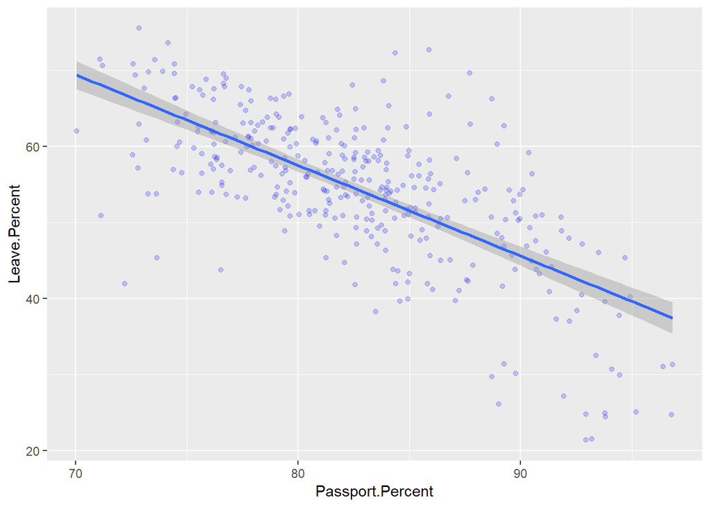

There is reasonable correlation to support the proposition, but it’s clearly not the full picture as there are a few groups of outliers.

Note that as the correlation between Passport.Percent and No.Passport.Percent is -1, one of these should be excluded from a prediction model as they’re saying the same thing.

## Social Grade

As a reminder:

| Grouping | Description | % UK Population |
| --- | --- | --- |
| AB.Percent | Higher & intermediate managerial, administrative, professional jobs | 22.17 |
| C1.Percent | Supervisory, clerical & junior managerial, administrative, professional jobs | 30.84 |
| C2.Percent | Skilled manual occupations | 20.94 |
| DE.Percent | Semi-skilled & unskilled manual occupations, Unemployed and lowest grade jobs | 26.05 |

PROPOSITION:

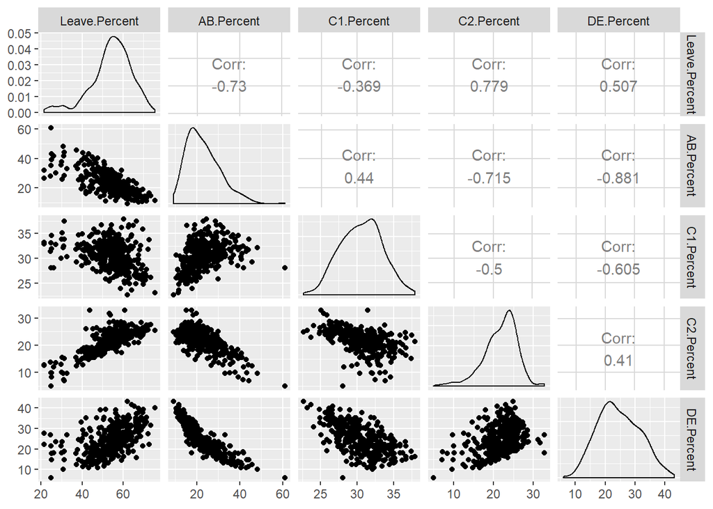

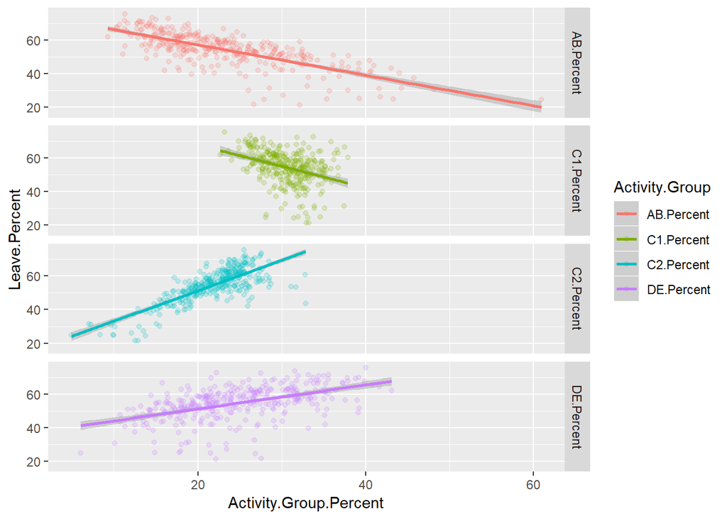

## Other Variables

PROPOSITION:

1. High EU Funding in a local authority will lead to a lower Leave vote.
2. Lower average House Prices is linked to a higher Leave vote.
3. Lower average Income is linked to a higher Leave vote.

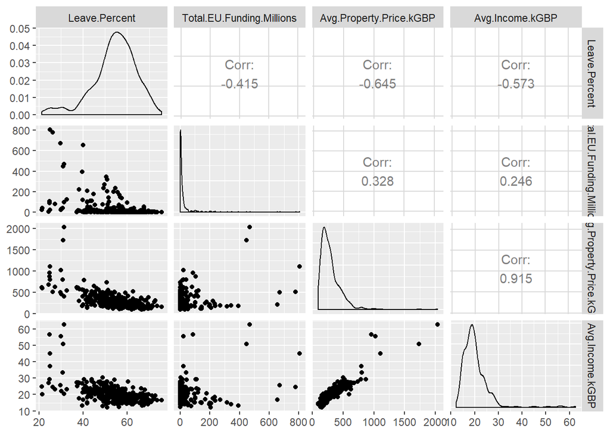

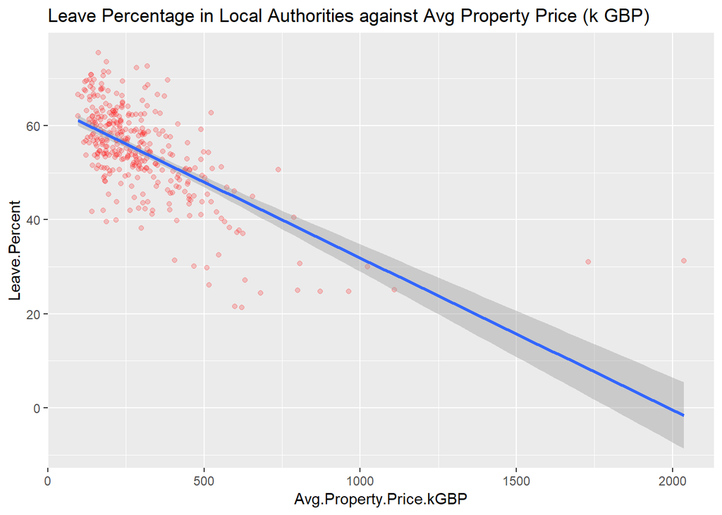

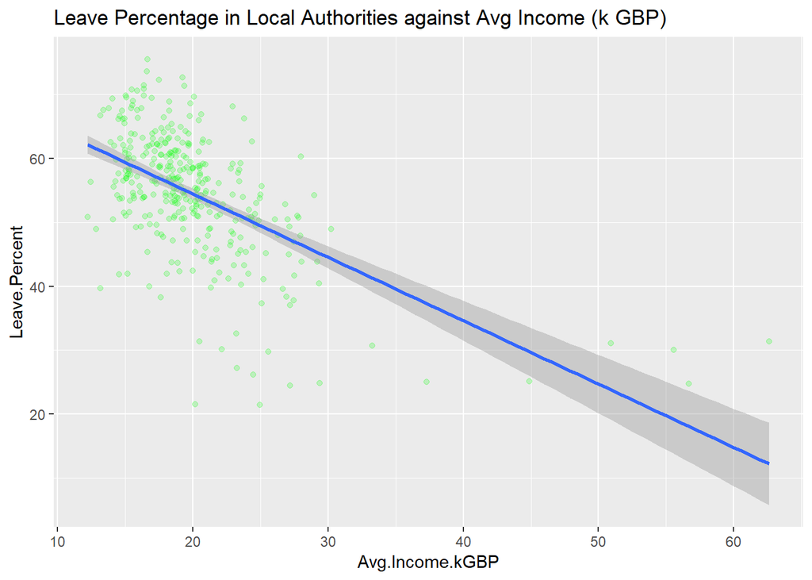

The correlations for Average House Prices and Average Income tend toward supporting their propositions but are not particularly strong. The outliers on these two variables can be found in the London region.

Note that as the correlation between Avg.Property.Price.kGBP and Avg.Income.kGBP is very high, it’s less likely that a prediction model would include both of these.

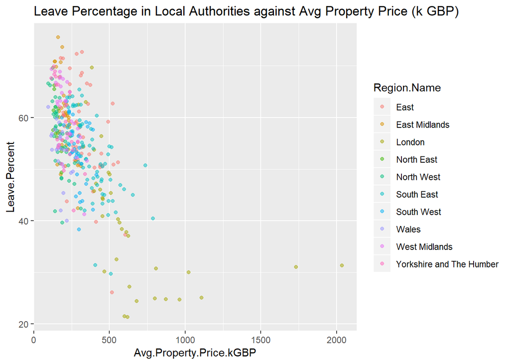

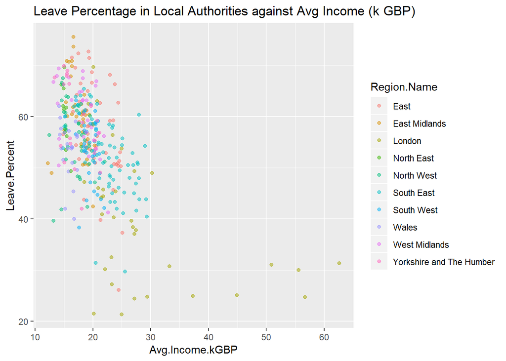

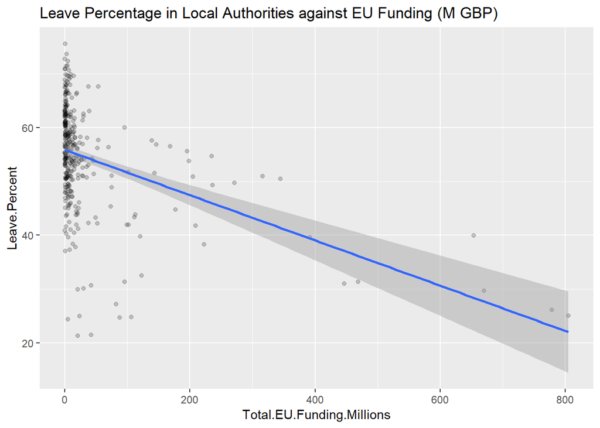

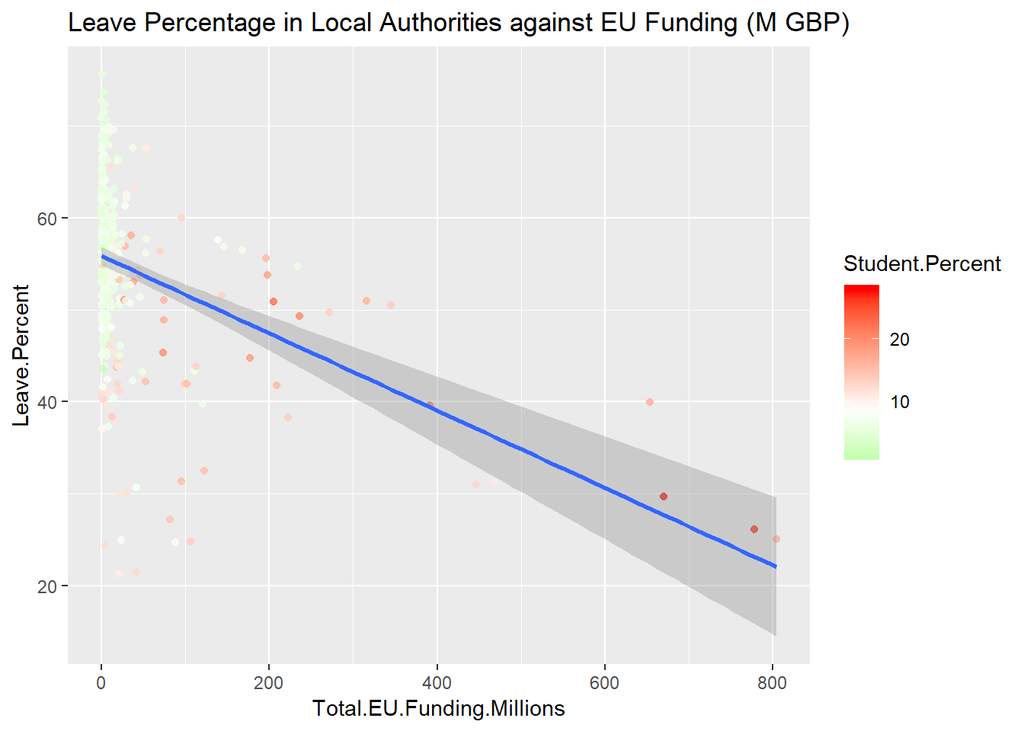

## Appendix 1: Correlation to Turnout

As we saw within Age Demographics there are some correlation patterns between the population characteristics and the turnout percentage which are suggestive of the sampling that happened from that population when individuals decided to vote.

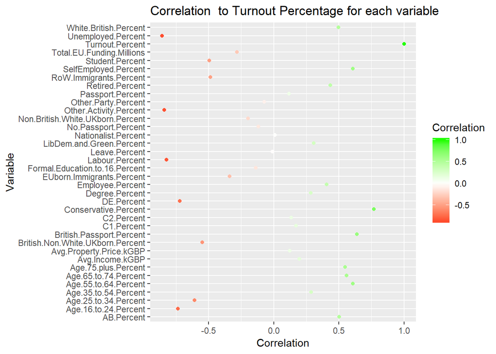

| Variable | Correlation |
| --- | --- |
| Turnout.Percent | 1.0000000 |
| Unemployed.Percent | -0.8565775 |
| Other.Activity.Percent | -0.8396119 |
| Labour.Percent | -0.8223386 |
| Conservative.Percent | 0.7690693 |
| Age.16.to.24.Percent | -0.7351880 |
| DE.Percent | -0.7209574 |
| British.Passport.Percent | 0.6392810 |
| Age.25.to.34.Percent | -0.6084077 |
| SelfEmployed.Percent | 0.6081559 |
| Age.55.to.64.Percent | 0.6079245 |

## Appendix 2: Significant Correlations between Variables

For this purpose I’ve taken signifance to be an absolute value of 0.8 or higher. This list contains those combinations already highlighted above and also some combinations which occur within a themed group because the total across the variables within that group has to add up to 100%.

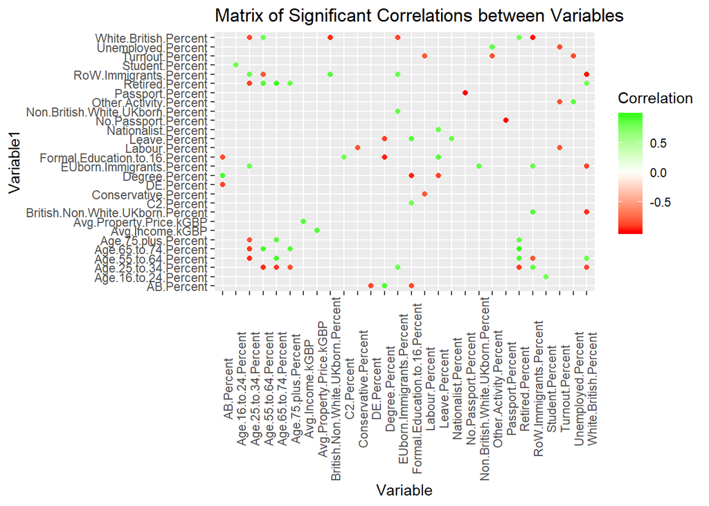

| Variable1 | Variable | Correlation |
| --- | --- | --- |
| Passport.Percent | No.Passport.Percent | -1.0000000 |
| RoW.Immigrants.Percent | White.British.Percent | -0.9884733 |
| Formal.Education.to.16.Percent | Degree.Percent | -0.9675027 |
| Retired.Percent | Age.65.to.74.Percent | 0.9654370 |
| British.Non.White.UKborn.Percent | White.British.Percent | -0.9464225 |
| Age.55.to.64.Percent | Age.25.to.34.Percent | -0.9449629 |
| Age.65.to.74.Percent | Age.55.to.64.Percent | 0.9385997 |
| AB.Percent | Degree.Percent | 0.9301124 |
| Age.65.to.74.Percent | Age.25.to.34.Percent | -0.9179972 |
| Retired.Percent | Age.55.to.64.Percent | 0.9156690 |
| Avg.Income.kGBP | Avg.Property.Price.kGBP | 0.9151023 |
| RoW.Immigrants.Percent | British.Non.White.UKborn.Percent | 0.9127276 |
| Formal.Education.to.16.Percent | Leave.Percent | 0.9066375 |
| Age.75.plus.Percent | Age.65.to.74.Percent | 0.9003235 |
| Retired.Percent | Age.25.to.34.Percent | -0.8997368 |
| Degree.Percent | Leave.Percent | -0.8869838 |
| DE.Percent | AB.Percent | -0.8814635 |
| Other.Activity.Percent | Unemployed.Percent | 0.8763132 |
| EUborn.Immigrants.Percent | White.British.Percent | -0.8723932 |
| White.British.Percent | Age.25.to.34.Percent | -0.8615443 |
| Retired.Percent | Age.75.plus.Percent | 0.8591256 |
| AB.Percent | Formal.Education.to.16.Percent | -0.8583125 |
| EUborn.Immigrants.Percent | Non.British.White.UKborn.Percent | 0.8567670 |
| Unemployed.Percent | Turnout.Percent | -0.8565775 |
| RoW.Immigrants.Percent | EUborn.Immigrants.Percent | 0.8546197 |
| RoW.Immigrants.Percent | Age.25.to.34.Percent | 0.8526306 |
| Nationalist.Percent | Leave.Percent | 0.8446427 |
| Other.Activity.Percent | Turnout.Percent | -0.8396119 |
| White.British.Percent | Age.55.to.64.Percent | 0.8357180 |
| Age.75.plus.Percent | Age.25.to.34.Percent | -0.8297353 |
| EUborn.Immigrants.Percent | Age.25.to.34.Percent | 0.8245039 |
| Labour.Percent | Turnout.Percent | -0.8223386 |
| RoW.Immigrants.Percent | Age.55.to.64.Percent | -0.8197871 |
| Student.Percent | Age.16.to.24.Percent | 0.8190096 |
| Labour.Percent | Conservative.Percent | -0.8146357 |
| C2.Percent | Formal.Education.to.16.Percent | 0.8095630 |
| White.British.Percent | Retired.Percent | 0.8028784 |

# Data Modeling

## Introduction

In creating a data model it’s important to remember that its objective is to predict results as accurately as possible without overfitting. It’s not to find causality - the resulting model formula does not mean that these are the variables which have caused the result.

## Modeling the Data

### Drilling Down on Variable Combinations

As there are over 30 variables the number of combinations is immense. Therefore I wanted to find a way to narrow this down.

My idea was to use “leaps” functionality to take the 20 “best” subsets of variables for each number of variables. My assumption is that the combination with the lowest RMSE for each No of Variables will be one of these subsets. These are then exported with the following format showing which variables are included:

| No. of Variables | Variable1 | Variable2 | … | Variable N |
| --- | --- | --- | --- | --- |
| 1 (best Leaps combo 1 variable) | True or False | True or False | … | True or False |
| 1.1 (2nd best Leaps combo) | True or False | True or False | … | True or False |
| … |  |  |  |  |
| 1.20 (20th best Leaps combo) | True or False | True or False | … | True or False |
| 2 | True or False | True or False | … | True or False |
| … |  |  |  |  |
| 31.20 (20th combo 31 variables) | True or False | True or False | … | True or False |

I’ve then processed them in Excel to return a dataframe best_subsets which contains a list of the combinations of variables to run through a Cross Validation routine. (Why Excel? Simply because it seemed so much easier to do that way). The returned data is in the format:

```
Variable1 + Variable2 + Variable3 + ... + VariableN
```

only for those variables which are True in each line.

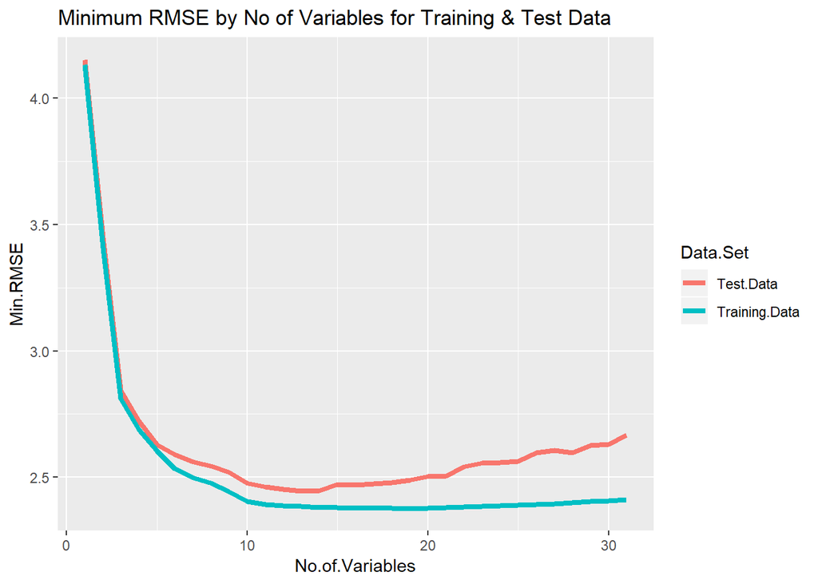

The number of variables which gives the minimum Test RMSE for the combination giving the minimum Training RMSE proves to be 12 variables and the combination which gave this result was:

```
  Age.16.to.24.Percent + Age.35.to.54.Percent + Age.75.plus.Percent + Employee.Percent + Retired.Percent
  + Degree.Percent + Conservative.Percent + Nationalist.Percent + Non.British.White.UKborn.Percent
  + RoW.Immigrants.Percent + Avg.Income.kGBP + C1.Percent
```

This will now be my starting point for creating a linear model.

Searching for the best model I’ll start with a linear regression as defined above and then try to improve it by changing variables. Then I’ll look to beat the Root Mean Square Error on the Test Data with other modeling types. The models below all apply to a 75% Training, 25% Test split.

### Linear Regression Model

#### Training Data Coefficients

Fitting linear model: Leave.Percent ~ Age.16.to.24.Percent + Age.35.to.54.Percent + Age.75.plus.Percent + Employee.Percent + Retired.Percent + Degree.Percent + Conservative.Percent + Nationalist.Percent + Non.British.White.UKborn.Percent + RoW.Immigrants.Percent + Avg.Income.kGBP + C1.Percent

|  | Estimate | Std. Error | t value | Pr(>\|t\|) |
| --- | --- | --- | --- | --- |
| **(Intercept)** | 25.54 | 11.03 | 2.315 | 0.02143 |
| **Age.16.to.24.Percent** | 0.5375 | 0.1907 | 2.819 | 0.00521 |
| **Age.35.to.54.Percent** | 0.409 | 0.15 | 2.727 | 0.006856 |
| **Age.75.plus.Percent** | -0.2008 | 0.2108 | -0.9529 | 0.3416 |
| **Employee.Percent** | 0.1817 | 0.07785 | 2.333 | 0.02043 |
| **Retired.Percent** | 0.9421 | 0.1602 | 5.88 | 1.316e-08 |
| **Degree.Percent** | -0.8835 | 0.04703 | -18.79 | 1.418e-49 |
| **Conservative.Percent** | 0.1677 | 0.01847 | 9.083 | 3.44e-17 |
| **Nationalist.Percent** | 0.5395 | 0.05045 | 10.69 | 3.393e-22 |
| **Non.British.White.UKborn.Percent** | -0.6017 | 0.3453 | -1.742 | 0.08266 |
| **RoW.Immigrants.Percent** | 0.2175 | 0.04465 | 4.871 | 1.984e-06 |
| **Avg.Income.kGBP** | 0.2324 | 0.05429 | 4.281 | 2.657e-05 |
| **C1.Percent** | -0.3483 | 0.07419 | -4.694 | 4.428e-06 |

Summary Stats on Training Data for Linear Regression Model1

| RMSE | R-Squared | Adj.R-Squared |
| --- | --- | --- |
| 2.423172 | 0.9384373 | 0.9354584 |

RMSE for Test Data

|  | x |
| --- | --- |
| RMSE | 2.344537 |

So the fitted model, with the coefficients taken from the Estimate column, is the formula:

```
  Leave.Percent = 25.54 + 0.5375 * Age.16.to.24.Percent + 0.409 * Age.35.to.54.Percent
                - 0.2008 * Age.75.plus.Percent + 0.1817 * Employee.Percent + 0.9421 * Retired.Percent
                - 0.8835 * Degree.Percent + 0.1677 * Conservative.Percent + 0.5395 * Nationalist.Percent
                - 0.6017 * Non.British.White.UKborn.Percent + 0.2175 * RoW.Immigrants.Percent
                + 0.2324 * Avg.Income.kGBP - 0.3483 * C1.Percent
```

This model gives a R-Squared on the Training Data which is fairly close to 1 (which is the best result possible) and the Adjusted R-Squared (which takes into account the number of variables and therefore helps to identify overfitting) is only a little less. The RMSE of the Test Data (2.3445) is now the value we want to beat with other models.

Looking at the coefficient table in the Pr(>|t|) column both Age.75.plus.Percent and Non.British.White.UKborn.Percent are unusually high for such a model. However despite this I’ve not found any other combinations of variables (including removing these) which, when modeled, give a better result than the combination above.

#### Error Distribution in Linear Model

In order to get a visual idea of the accuracy of the predictions made for the Test Data by the model here are two plots.

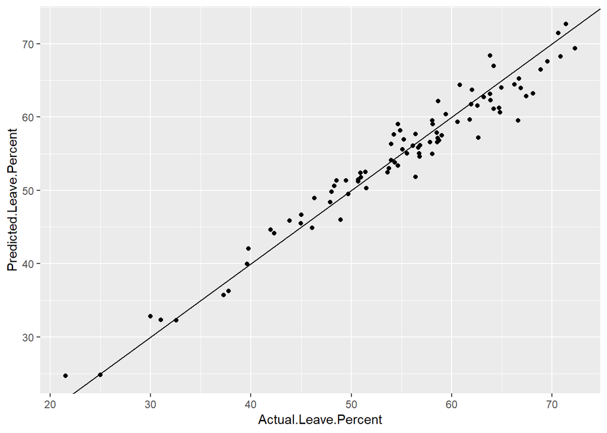

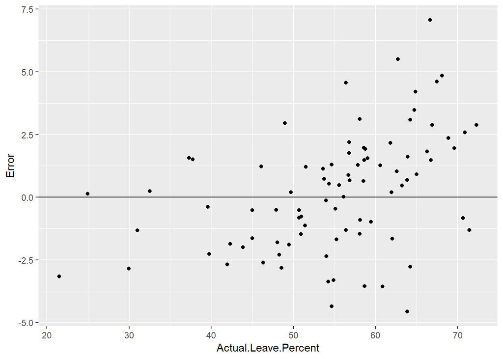

Errors vs Model > 4%

| Error.vs.Model | LA Name | Leave.Percent |
| --- | --- | --- |
| 4.615438 | Blackpool | 67.46 |
| -4.354781 | Swindon | 54.66 |
| 4.851689 | Harlow | 68.10 |
| -4.570845 | Thanet | 63.85 |
| 5.503342 | Epping Forest | 62.69 |
| 4.208150 | South Staffordshire | 64.85 |
| 4.568770 | Ribble Valley | 56.39 |
| 7.072230 | Burnley | 66.61 |

Looking at the Local Authorities with the largest errors doesn’t immediately suggest a particular pattern.

### CART Model

Although CART modeling will often be more adapted to discrete results, it can also be used for continuous variables. The particular advantage comes in the simplicity of the model which can easily be used in flowchart instructions.

Here we’ll consider a model using just the variables from the linear model above, and then one using all available variables.

RMSE for Test Data

|  | x |
| --- | --- |
| RMSE | 4.16874 |

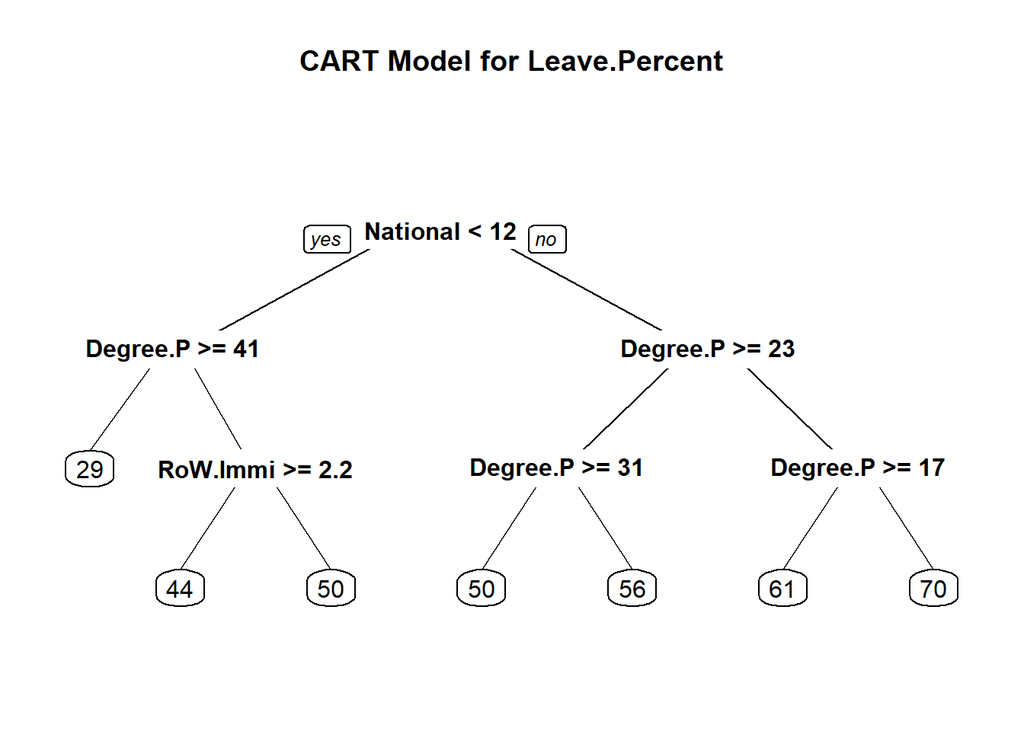

With only 7 different predicted results it’s not surprising that the RMSE for this model is higher than the linear model.

RMSE for Test Data

|  | x |
| --- | --- |
| RMSE | 4.783948 |

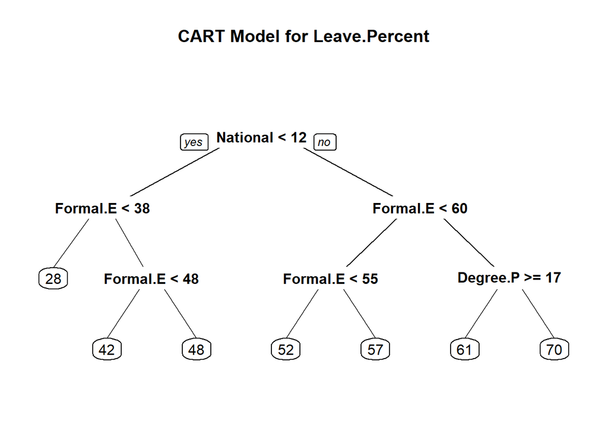

Surprisingly in this model, making all of the variables available not only does not create a more complicated tree, but also results in a worse RMSE. It’s interesting to note that in both CART trees Education fields are in more than one level of the tree. Therefore it’s worth investigating a polynomial regression model.